# 10 Scrolls at a Time

Mapping the Rhythm of My Scrolling Addiction

## It starts like this -

I open TikTok for *“just a minute”*

*One* scroll….

becomes *two*…

then *ten*…

then suddenly I have time-travelled through *hundreds* of videos

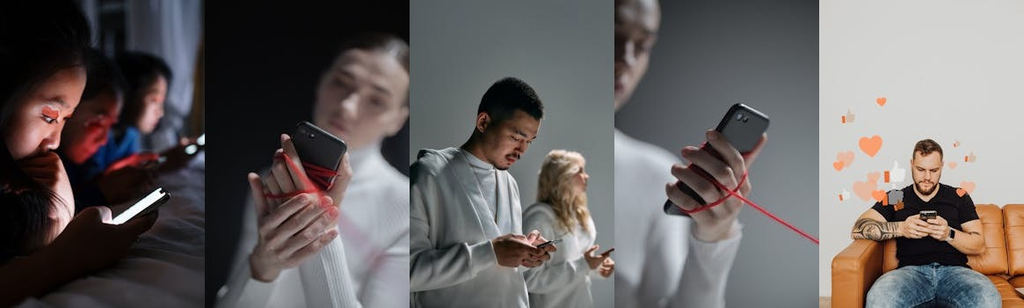

## But what actually makes me **stop** and **watch**?

What **themes** keep popping up?

When do certain **feelings** hit hardest?

In this visual data story, I use three plots *(and far too much of my own TikTok data)* to uncover the rhythm behind my daily **doom-scrolling addiction**

## Just One More Video…

TikTok runs on fast dopamine - short, snappy, scroll-stopping content - but how short is *short* ?

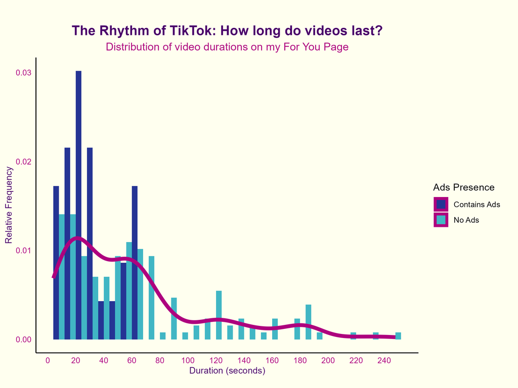

Histogram of TikTok video durations, grouped by ad presence with a density curve overlay

This plot shows how long the videos on my For You Page really are and whether they come with a side of *capitalism*.

Quick beats are dominating

## **Wait… Why Is That Video Longer?**

Just when I thought I have figured out the rhythm something shifts!

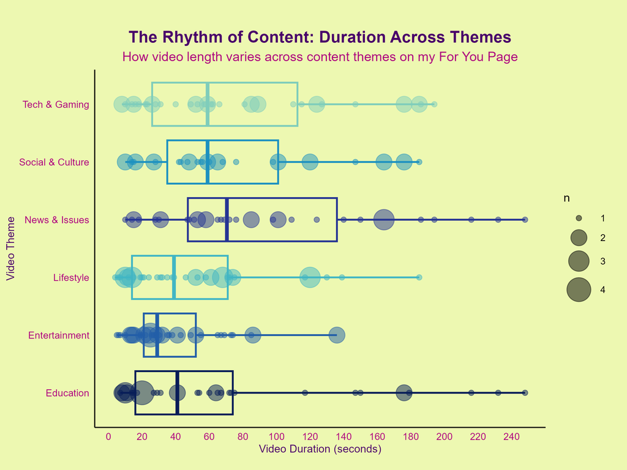

A box plot showing how video lengths vary across different content themes with overlapping dot-count sizes representing frequency

This plot breaks down video duration by **general theme** which shows how the content type controls the tempo

General themes bring tempo as not all content dances to the same beat

## **Ooh! Why Does That Hit Different on a Thursday?**

*Scroll….*

*Scroll….*

What is this feeling…

so **sudden**….and *new*

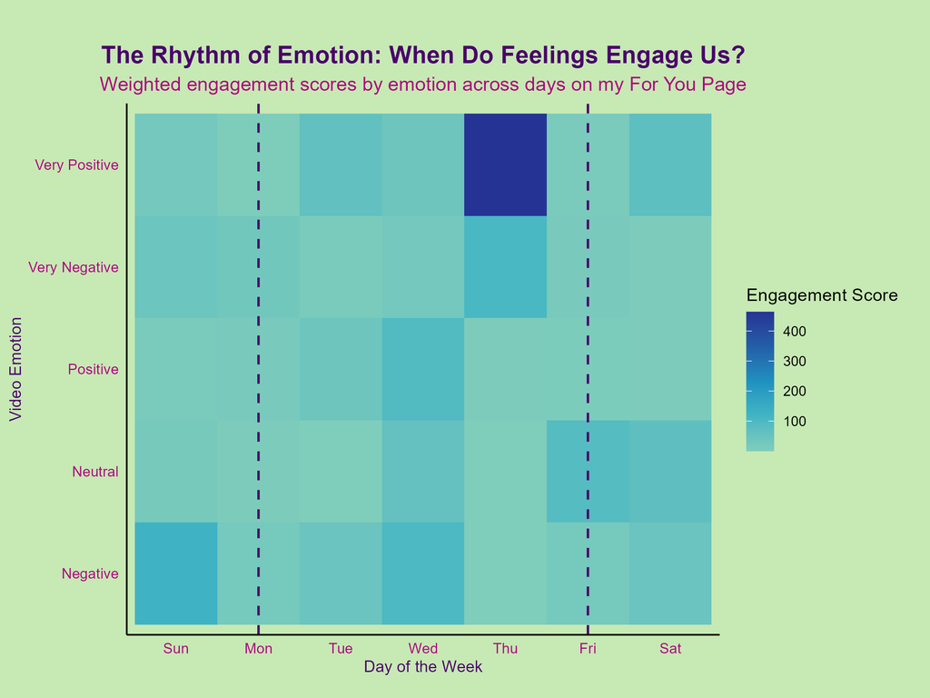

A heat map showing weighted engagement scores for different video emotions across each day of the week. Darker tiles represent higher engagement

This heat map tracks the engagement by **emotion** and **day of the week**. I used a weighted score based on likes, comments, and shares

- For You Page video content that express high energy emotions like happiness and excitement tend to receive more engagement in the middle of the week, especially on Wednesdays and Thursdays
- Calmer and sadder video content quietly rise in engagement on Sundays
- The video content’s emotional tone appears to influence how much viewers interact, we can see this from the likes, comments, and shares are not evenly spread
- This heat map reveals how emotional themes pulse through the week which suggests that creators may be timing content to align with the shifting moods
- The dashed line splits the week by weekend and weekday to highlight the shift in emotional engagement as the tempo of the week changes